# U3L9 - Nonlinear Classification

## Front Matter

```r
#Delete all objects from Environment - Use with caution
remove(list = ls())

#Load Libraries
library(tidyverse)
library(palmerpenguins)
library(FNN) #For k-nearest neighbors
library(rpart) #For classification and regression trees
library(rattle) #For creating nice visualizations of trees
#Read in Data
titanic <- read.csv("../../sample_data/L08_titanic3.csv")
```

## Example - k-Nearest Neighbors in R using Titanic Data

#### Part a - Prepare the data

```r
#Check for NA's
apply(X = titanic, MARGIN = 2, FUN = function(x) sum(is.na(x)))   #margin = 2 means column while 1 means row
```

```
## Survived   Pclass      Sex      Age Siblings    Parch     Fare
##        0        0        0        0        0        0        0
```

```r
#Create Indicators
titanic <-
  titanic %>%
  mutate(Male = ifelse(Sex == "male", 1, 0))


#Create a vector to hold the names of input variables
xvars <- c("Age", "Male", "Fare", "Pclass")
#Scale the input variables
titanic[, xvars] <- scale(x = titanic[, xvars], center = TRUE, scale = TRUE)


#Perform Training/Validation Split
set.seed(123)
trainInd <- sample(1:nrow(titanic), floor(0.85 * nrow(titanic)))
set.seed(NULL)

Train <- titanic[trainInd, ]
Validation <- titanic[-trainInd, ]
```

#### Part b - Build the kNN model using 5 nearest neighbors

```r
#Build kNN model with k = 5
knnRes <- knn(train = Train[, xvars, drop = FALSE],
              test = Validation[, xvars, drop =FALSE],
              cl = Train$Survived,
              k = 5) #drop = false prevents coercion down to a vector for 1 column dataframe
#View Results
#knnRes #Generally, do not include this in your code
```

#### Part c - Add the predictions to the validation set and name the new variable predSurvival.

```r
#Add Predictions to Validation Data (name them predSurvival)
Validation <-
  Validation %>%
  mutate(predSurvival = knnRes)
```

#### Part d - Create a confusion matrix

```r
#Create a confusion matrix (rows = predictions, columns = true status)
table(Validation$predSurvival, Validation$Survived)
```

```
##
##       No Yes
##   No  68  14
##   Yes 12  40
```

#### Part e - Find the overall accuracy of the classifier

```r
#Calculate the accuracy
mean(Validation$Survived == Validation$predSurvival)
```

```
## [1] 0.8059701
```

## Example - Determining the Optimal Number of Nearest Neighbors using a Loop

```r
#Initialize
maxK <- 100
accVec <- rep(NA, maxK)

#Loop for using various values of k
for(i in 1:maxK){
  #Build kNN model
  knnRes <- knn(train = Train[, xvars, drop = FALSE],
              test = Validation[, xvars, drop =FALSE],
              cl = Train$Survived,
              k = i)
  #Add predictions to validation data
  Validation <- Validation %>%
      mutate(predSurvival = knnRes)

   accVec[i] <- mean(Validation$Survived == Validation$predSurvival)
  #Store the accuracy result

}

#View the accuracy values
which.max(accVec)
```

```
## [1] 12
```

```r
accVec[which.max(accVec)]
```

```
## [1] 0.8432836
```

#### Part b - Create a plot showing the accuracy values as a function of k

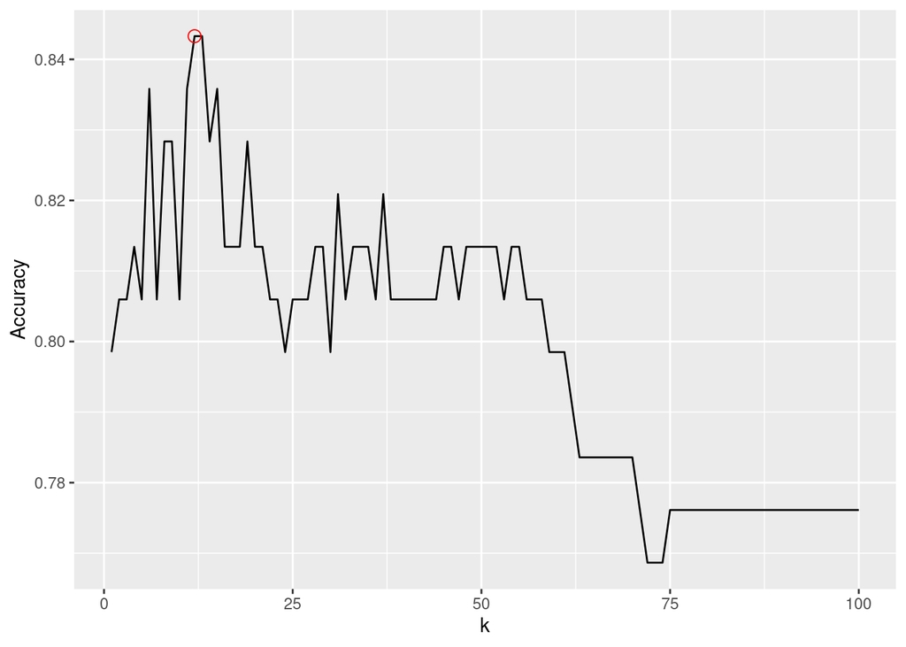

```r
#Create a temporary data frame for plotting
tempDF <- data.frame(k = 1:maxK, Accuracy = accVec)

#Create a plot showing accuracy as a function of k
ggplot(tempDF, aes(x = k, y = Accuracy)) + geom_line() + geom_point(data = tempDF[which.max(accVec),], color = "red", shape = 1, size = 3)
```

#### Part c - Repeat the process using a random seed of 321. Which value of k would you choose?

```r
#Perform Training/Validation Split
set.seed(321)
trainInd <- sample(1:nrow(titanic), floor(0.85 * nrow(titanic)))
set.seed(NULL)

Train <- titanic[trainInd, ]
Validation <- titanic[-trainInd, ]

#Initialize
maxK <- 75
accVec2 <- rep(NA, maxK)

#Loop for using various values of k
for(i in 1:maxK){
  #Build kNN model
  knnResTemp <-
    knn(train = Train[ , xvars, drop = FALSE],
        test = Validation[ , xvars, drop = FALSE],
        cl = Train$Survived,
        k = i)

  #Add predictions to validation data
  Validation <-
    Validation %>%
    mutate(predSurvival = knnResTemp)

  #Store result
  accVec2[i] <- mean(Validation$Survived == Validation$predSurvival)
}

#View the accuracy values
accVec2
```

```
##  [1] 0.8283582 0.8656716 0.8432836 0.8656716 0.8731343 0.8582090 0.8432836
##  [8] 0.8432836 0.8582090 0.8432836 0.8358209 0.8208955 0.8358209 0.8283582
## [15] 0.8432836 0.8358209 0.8432836 0.8432836 0.8507463 0.8283582 0.8358209
## [22] 0.8059701 0.8208955 0.8208955 0.8283582 0.8208955 0.8208955 0.8134328
## [29] 0.8059701 0.8059701 0.8134328 0.8134328 0.8134328 0.8134328 0.8059701
## [36] 0.8134328 0.8134328 0.8208955 0.8208955 0.8283582 0.8208955 0.8208955
## [43] 0.8283582 0.8283582 0.8283582 0.8283582 0.8283582 0.8283582 0.8283582
## [50] 0.8283582 0.8208955 0.8283582 0.8208955 0.8134328 0.8134328 0.8134328
## [57] 0.8134328 0.8134328 0.8134328 0.8134328 0.8208955 0.8208955 0.8208955
## [64] 0.8208955 0.8134328 0.8134328 0.8134328 0.8134328 0.8134328 0.8134328
## [71] 0.8134328 0.8134328 0.8134328 0.8059701 0.8134328
```

```r
#Determine the optimal number of neighbors
which.max(accVec2)
```

```
## [1] 5
```

```r
#Determine the optimal accuracy
accVec2[which.max(accVec2)]
```

```
## [1] 0.8731343
```

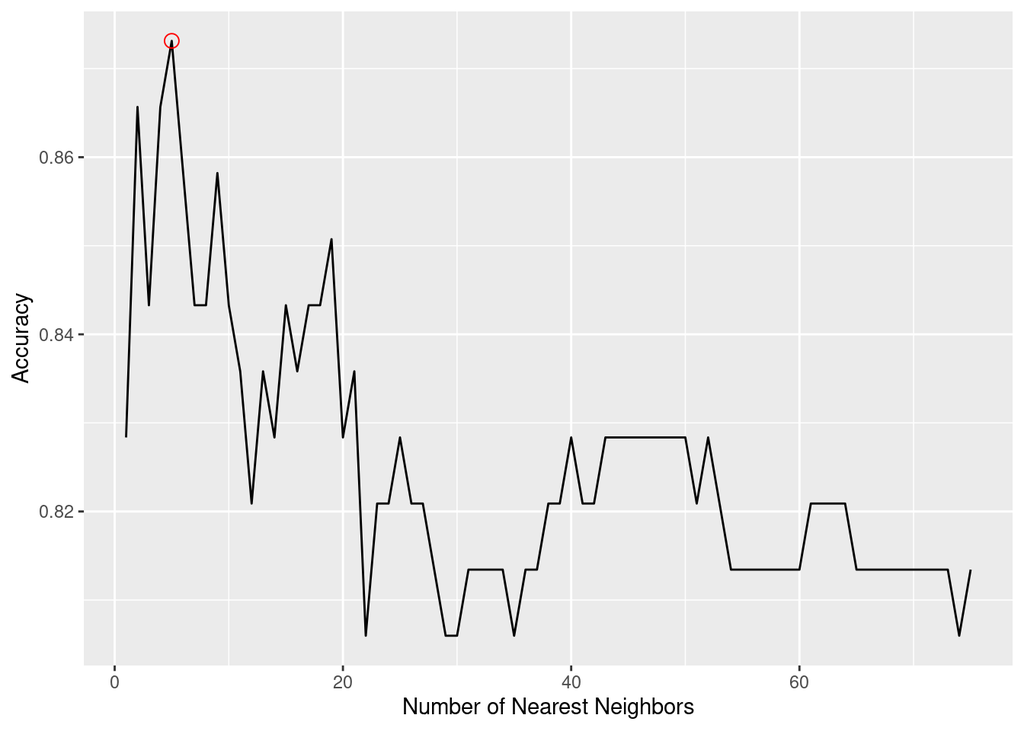

```r
#Create a temporary data frame for plotting
tempDF2 <- data.frame(k = 1:maxK, Accuracy = accVec2)

#Create a plot showing accuracy as a function of k
ggplot(data = tempDF2,
       mapping = aes(x = k, y = Accuracy)) +
  geom_line() +
  labs(x = "Number of Nearest Neighbors",
       y = "Accuracy") +
  geom_point(data = tempDF2[which.max(accVec2), ],
             color = "red", shape = 1, size =3)
```

#### Part d - k-fold Cross Validation

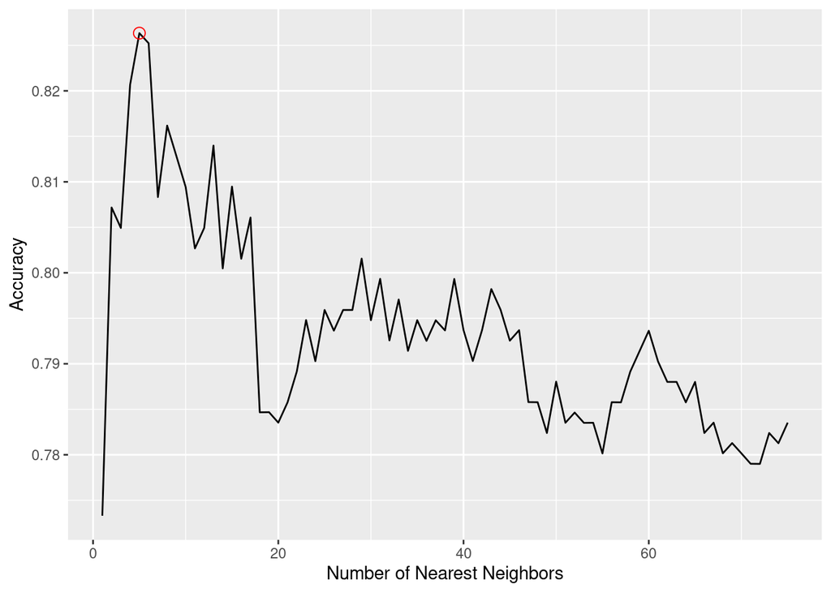

```r
#Create fold values
num_folds <- 10
folds <- cut(x = 1:nrow(titanic), breaks = num_folds, labels = FALSE)

set.seed(123)
folds <- sample(folds) #randomly permute the fold values
set.seed(NULL)

#Initialize
maxK <- 75
accMatrix <- matrix(NA, nrow = num_folds, ncol = maxK)

#Loop for using various values of k
for(i in 1:num_folds){
  #Perform Data Split
  valInd <- which(folds == i)
  Validation <- titanic[valInd, ]
  Train <- titanic[-valInd, ]

  for(j in 1:maxK){
    #Build kNN model
    knnResTemp <-
    knn(train = Train[ , xvars, drop = FALSE],
        test = Validation[ , xvars, drop = FALSE],
        cl = Train$Survived,
        k = j)
    #Add predictions to validation data
    Validation <-
      Validation %>%
      mutate(predSurvival = knnResTemp)

    #Store result
    accMatrix[i,j] <- mean(Validation$Survived == Validation$predSurvival)
    }
}

#For each value of k, average accuracy values across the 10 folds
accMeans <- apply(accMatrix, 2, mean)

#Create a temporary data frame for plotting
tempDF <- data.frame(k = 1:maxK, Accuracy = accMeans)

#Create a plot showing accuracy as a function of k
ggplot(data = tempDF,
       mapping = aes(x = k, y = Accuracy)) +
  geom_line() +
  labs(x = "Number of Nearest Neighbors",
       y = "Accuracy") +
  geom_point(data = tempDF[which.max(accMeans), ],
             color = "red", shape = 1, size =3)
```

## Example - Classification Tree in R using Titanic Data

#### Part a - Perform an 85/15 training/validation split using a seed of 123.

```r
#Read Data into R in case original dataset was modified in earlier example
titanic <- read.csv("../../sample_data/L08_titanic3.csv")

#Perform Training/Validation Split
set.seed(123)
trainInd <- sample(1:nrow(titanic), floor(0.85 * nrow(titanic)))
set.seed(NULL)

Train <- titanic[trainInd, ]
Validation <- titanic[-trainInd, ]
```

#### Part b - Grow the classification tree. What are the first 2 splits?

```r
#Build the classification tree
classTree <- rpart(Survived  ~ ., data = Train, method = "class")
#If Survived was a 0/1 indicator, convert Survived to a factor to ensure Classification
#NOTE: method = "anova" was used for a regression tree

#Display a summary of the tree
summary(classTree) #Generally speaking, do not include this in your markdown
```

```
## Call:
## rpart(formula = Survived ~ ., data = Train, method = "class")
##   n= 753
##
##           CP nsplit rel error    xerror       xstd
## 1 0.43402778      0 1.0000000 1.0000000 0.04630552
## 2 0.02777778      1 0.5659722 0.5659722 0.03924008
## 3 0.02083333      3 0.5104167 0.5277778 0.03824451
## 4 0.01388889      4 0.4895833 0.5208333 0.03805523
## 5 0.01000000      6 0.4618056 0.5034722 0.03757040
##
## Variable importance
##      Sex     Fare   Pclass    Parch      Age Siblings
##       51       18       14        7        6        4
##
## Node number 1: 753 observations,    complexity param=0.4340278
##   predicted class=No   expected loss=0.3824701  P(node) =1
##     class counts:   465   288
##    probabilities: 0.618 0.382
##   left son=2 (488 obs) right son=3 (265 obs)
##   Primary splits:
##       Sex      splits as  RL,           improve=102.125100, (0 missing)
##       Pclass   < 2.5      to the right, improve= 38.553060, (0 missing)
##       Fare     < 10.48125 to the left,  improve= 37.175450, (0 missing)
##       Parch    < 0.5      to the left,  improve=  8.624408, (0 missing)
##       Siblings < 0.5      to the left,  improve=  6.381029, (0 missing)
##   Surrogate splits:
##       Parch    < 0.5      to the left,  agree=0.684, adj=0.102, (0 split)
##       Fare     < 77.6229  to the left,  agree=0.675, adj=0.075, (0 split)
##       Siblings < 0.5      to the left,  agree=0.656, adj=0.023, (0 split)
##       Age      < 15.5     to the right, agree=0.652, adj=0.011, (0 split)
##
## Node number 2: 488 observations
##   predicted class=No   expected loss=0.1905738  P(node) =0.6480744
##     class counts:   395    93
##    probabilities: 0.809 0.191
##
## Node number 3: 265 observations,    complexity param=0.02777778
##   predicted class=Yes  expected loss=0.2641509  P(node) =0.3519256
##     class counts:    70   195
```

[output cut: 77 more lines]

```
##
## Node number 55: 34 observations
##   predicted class=Yes  expected loss=0.2647059  P(node) =0.04515272
##     class counts:     9    25
##    probabilities: 0.265 0.735
##
## Node number 108: 18 observations
##   predicted class=No   expected loss=0.2777778  P(node) =0.02390438
##     class counts:    13     5
##    probabilities: 0.722 0.278
##
## Node number 109: 46 observations
##   predicted class=Yes  expected loss=0.3695652  P(node) =0.06108898
##     class counts:    17    29
##    probabilities: 0.370 0.630
```

```r
# The improvement is the based on the GINI index
```

#### Part c - Create a visualization of the tree.

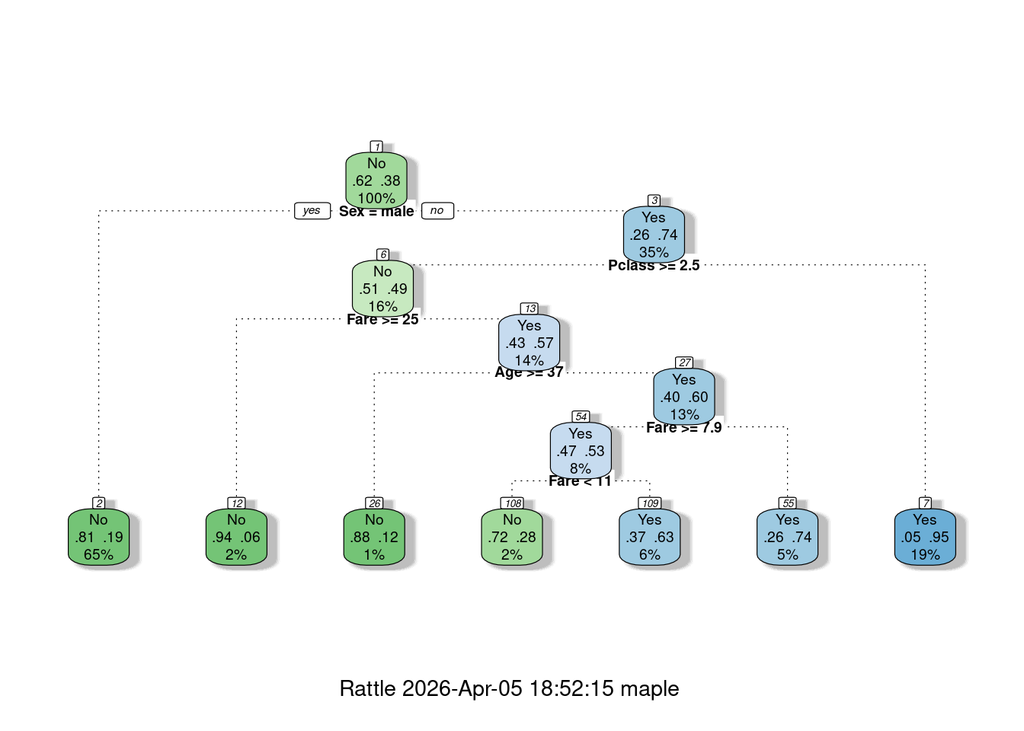

```r
#Visualize the tree (fancyRpartPlot is from the rattle package)
fancyRpartPlot(classTree, cex = .6)
```

#### Part e - Predict whether a 35 year-old female passenger who paid 50 for a class 2 ticket will survive

```r
predict(classTree, newdata = data.frame(Age = 35, Sex = "female", Fare = 50, Pclass = 2, Siblings = 0, Parch = 0))
```

```
##           No       Yes
## 1 0.04964539 0.9503546
```

#### Part f - Obtain predicted probabilities for the validation set

```r
#Find Predicted Probabilities
predProb <- predict(classTree, newdata = Validation, type = "prob")
#Returns a matrix with 1 row per obs in Validation, and 1 column per response class

#View first six probability predictions
head(predProb, 6)
```

```
##            No       Yes
## 1  0.80942623 0.1905738
## 3  0.72222222 0.2777778
## 7  0.80942623 0.1905738
## 12 0.04964539 0.9503546
## 22 0.80942623 0.1905738
## 27 0.80942623 0.1905738
```

#### Part g - Obtain predicted classes for the validation set

```r
#Determine predicted classes
predSurv <- predict(classTree, newdata = Validation, type = "class")

#Show the first six predictions
head(predSurv)
```

```
##   1   3   7  12  22  27
##  No  No  No Yes  No  No
## Levels: No Yes
```

NOTE: To obtain predictions for a regression tree, you can omit the `type =` specification.

#### Part h - Obtain Confusion matrix and calculate accuracy

```r
#Create the confusion Matrix
table(predSurv, Validation$Survived)
```

```
##
## predSurv No Yes
##      No  76  19
##      Yes  4  35
```

```r
#Calculate accuracy
mean(Validation$Survived == predSurv)
```

```
## [1] 0.8283582
```

NOTE: For a binary response, we could use the predicted probabilities to generate an ROC curve and/or find AUC.

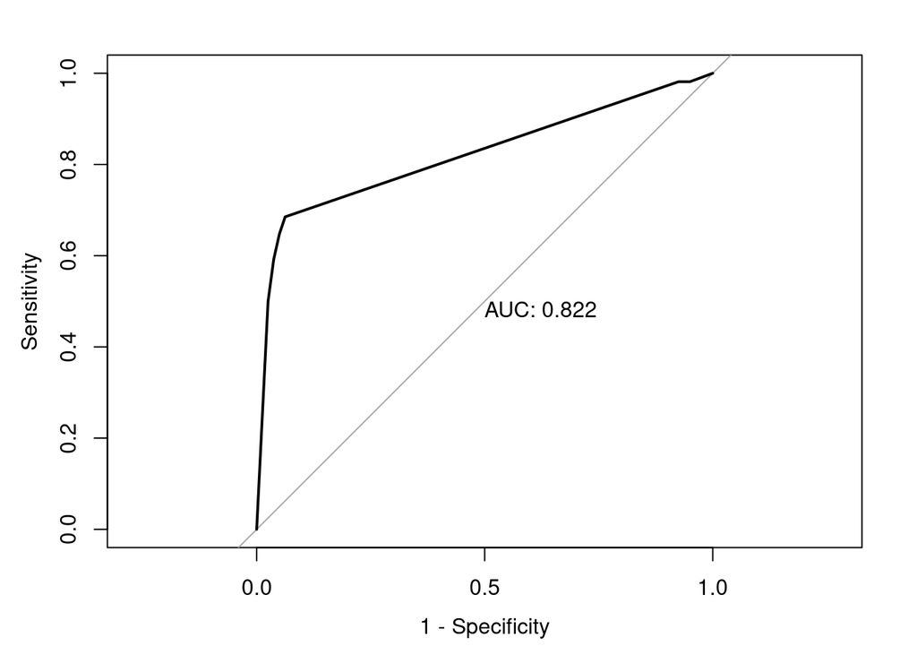

```r
rocCurve <- pROC::roc(response = Validation$Survived,
                      predictor = predProb[,2],
                      legacy.axes = TRUE,
                      print.auc = TRUE, plot = TRUE)
```

NOTE: For a regression tree, we could use the predicted responses to calculate MSE (or RMSE) for the validation set instead of the accuracy.

## Example - Determining Variable Importance

```r
summary(classTree)
```

```
## Call:
## rpart(formula = Survived ~ ., data = Train, method = "class")
##   n= 753
##
##           CP nsplit rel error    xerror       xstd
## 1 0.43402778      0 1.0000000 1.0000000 0.04630552
## 2 0.02777778      1 0.5659722 0.5659722 0.03924008
## 3 0.02083333      3 0.5104167 0.5277778 0.03824451
## 4 0.01388889      4 0.4895833 0.5208333 0.03805523
## 5 0.01000000      6 0.4618056 0.5034722 0.03757040
##
## Variable importance
##      Sex     Fare   Pclass    Parch      Age Siblings
##       51       18       14        7        6        4
##
## Node number 1: 753 observations,    complexity param=0.4340278
##   predicted class=No   expected loss=0.3824701  P(node) =1
##     class counts:   465   288
##    probabilities: 0.618 0.382
##   left son=2 (488 obs) right son=3 (265 obs)
##   Primary splits:
##       Sex      splits as  RL,           improve=102.125100, (0 missing)
##       Pclass   < 2.5      to the right, improve= 38.553060, (0 missing)
##       Fare     < 10.48125 to the left,  improve= 37.175450, (0 missing)
##       Parch    < 0.5      to the left,  improve=  8.624408, (0 missing)
##       Siblings < 0.5      to the left,  improve=  6.381029, (0 missing)
##   Surrogate splits:
##       Parch    < 0.5      to the left,  agree=0.684, adj=0.102, (0 split)
##       Fare     < 77.6229  to the left,  agree=0.675, adj=0.075, (0 split)
##       Siblings < 0.5      to the left,  agree=0.656, adj=0.023, (0 split)
##       Age      < 15.5     to the right, agree=0.652, adj=0.011, (0 split)
##
## Node number 2: 488 observations
##   predicted class=No   expected loss=0.1905738  P(node) =0.6480744
##     class counts:   395    93
##    probabilities: 0.809 0.191
##
## Node number 3: 265 observations,    complexity param=0.02777778
##   predicted class=Yes  expected loss=0.2641509  P(node) =0.3519256
##     class counts:    70   195
```

[output cut: 77 more lines]

```
##
## Node number 55: 34 observations
##   predicted class=Yes  expected loss=0.2647059  P(node) =0.04515272
##     class counts:     9    25
##    probabilities: 0.265 0.735
##
## Node number 108: 18 observations
##   predicted class=No   expected loss=0.2777778  P(node) =0.02390438
##     class counts:    13     5
##    probabilities: 0.722 0.278
##
## Node number 109: 46 observations
##   predicted class=Yes  expected loss=0.3695652  P(node) =0.06108898
##     class counts:    17    29
##    probabilities: 0.370 0.630
```

## Example - Node Size

Putting each observation into its own node would produce a Gini Index of 0, which suggests that each node is pure. Explain why this is not desirable.

## Example - Pruning the Tree

#### Part a - Using a complexity parameter (cp) value of 0.001, grow the tree.

```r
#Grow the tree and perform 10-fold CV
set.seed(123)
fullTree <- rpart(Survived ~ . , data = Train, method = "class", cp = 0.001, xval = 10)

#Display the cptable
fullTree$cptable
```

```
##            CP nsplit rel error    xerror       xstd
## 1 0.434027778      0 1.0000000 1.0000000 0.04630552
## 2 0.027777778      1 0.5659722 0.5659722 0.03924008
## 3 0.020833333      3 0.5104167 0.5277778 0.03824451
## 4 0.013888889      4 0.4895833 0.5381944 0.03852356
## 5 0.008680556      6 0.4618056 0.5347222 0.03843119
## 6 0.003472222     14 0.3888889 0.5069444 0.03766871
## 7 0.001000000     16 0.3819444 0.5034722 0.03757040
```

#### Part b - Plot the tree

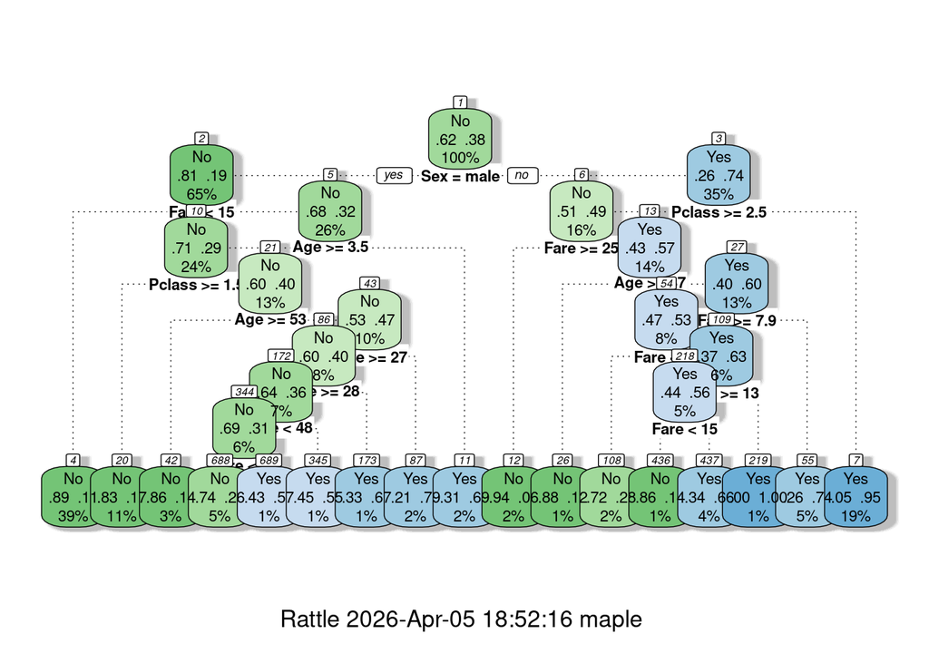

```r
fancyRpartPlot(fullTree, cex = 0.7)
```

#### Part c - Visualize the results of the cross validation procedure.

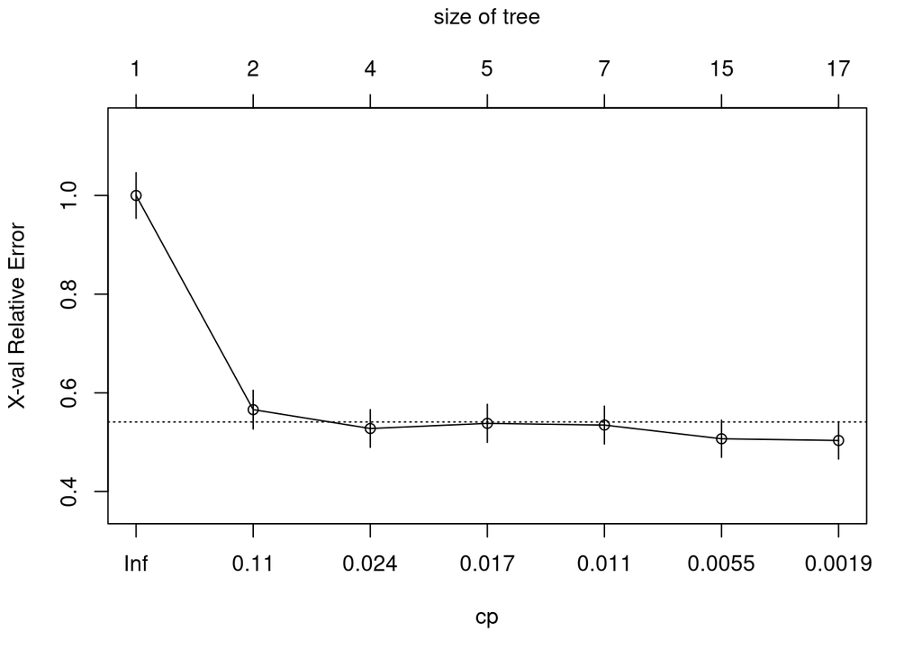

```r
plotcp(fullTree)
```

#### Part d - What is the optimal value of the complexity parameter based on minimizing the cross validation error?

```r
#Determine the row of cptable containing smallest CV error
cpRow <- which.min(fullTree$cptable[ , "xerror"])

#Determine optimal value of cp
cpChoiceMin <- fullTree$cptable[ , "CP"][cpRow]

#Display the choice
cpChoiceMin
```

```
##     7
## 0.001
```

#### Part e - What is the optimal value of the complexity parameter based on the 1se rule?

```r
#Determine the row of cptable containing smallest CV error
cpRow <- which.min(fullTree$cptable[ , "xerror"])

#Calculate min(xerror) + xstd
target <- fullTree$cptable[ , "xerror"][cpRow] +fullTree$cptable[ , "xstd"][cpRow]

#Determine which xerror values are less than target and select first such value
cpRow1se <- which(fullTree$cptable[ , "xerror"] < target)[1]

cpChoice1se <- fullTree$cptable[ , "CP"][cpRow1se]

#Display the choice
cpChoice1se
```

```
##          3
## 0.02083333
```

#### Part f - Prune the tree

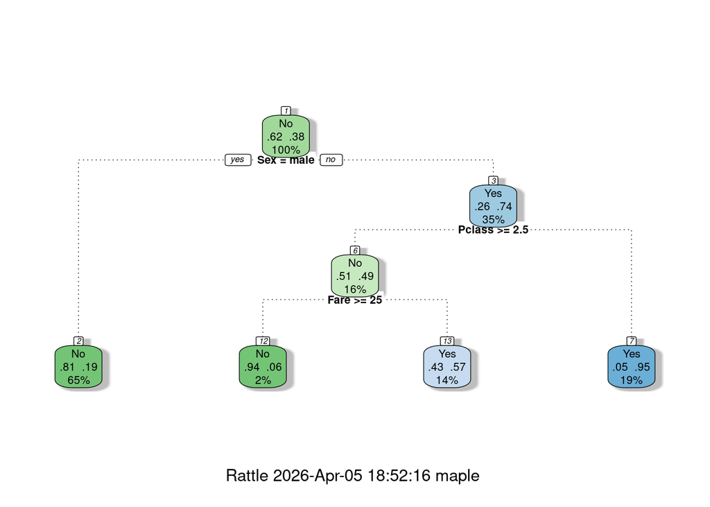

```r
#Prune the true
prunedTree <- prune(fullTree, cp=cpChoice1se)

#View the pruned tree
fancyRpartPlot(prunedTree, cex=0.65)
```

#### Part g - Using the pruned tree, find the validation set accuracy

```r
#Obtain the predicted classes
prunedPred <- predict(prunedTree, newdata = Validation, type = "class")

#Calculate the accuracy
mean(Validation$Survived == prunedPred)
```

```
## [1] 0.8208955
```